# Calibration calibration calibration ROUND 00

2019-03-14

#### Calibration, calibration, calibration. Like they said at the SNAK workshop. I need to *&$"ing calibrate otherwise my recordings are useless!

#### So, I'm going to try and answer some of the questions I've always wanted to :

#### 1) Do speaker playbacks show variation over time?

#### 2) How similar are the SMPs to each other?

#### 3) How similar are the SANKENs to each other?

```python
import datetime as dt
```

```python
print('time of report generation', dt.datetime.now())
```

```
('time of report generation', datetime.datetime(2019, 3, 27, 18, 2, 35, 34000))
```

### What was done:

I set up the microphones on an L-shaped azimuthal swivel aligned to the Vifa speaker (soldered 8/2/2018, used through the 2018 field season). The azimuthal swivel ensures that the mic remains at a fixed radial distance to the speaker, and only the direction of arrival of the speaker playback changes. Here is a very *bad* hand drawn schematic (note to self, need to find the photos!).

[figure not shown]

#### The setup:

The speaker + mics were mounted on tripods at a height of ~1m to avoid ground reflections. The speaker was placed 1.1 meters from the microphone to keep it in the far field, and to be able to recognise any reflections arising from the speaker-mic setup itself.

#### The playback:

The playback was a combination upward frequency sweeps and pure tones. The frequency sweeps were 10 ms long (tukey windowed) between 15-95 kHz. The pure tones were each 100 ms long between 10 to 94 kHz in steps of 1 kHz. Recordings and playback were performed with the Fireface 802. The Channel 9 of the Fireface 802 was used for the input, and channel 1 of the output was used. All playbacks and recordings were performed at 192 kHz sampling rate.

The Vifa speaker was driven by a 12V DC powered car amplifier (BASETECH AP 2100).

#### The microphones:

The same speaker playback was recorded at a variety of angles for each microphone model. There were three microphone models used:

#### 1) SMP Knowles

#### 2) SANKEN CO-100

#### 3) GRAS 1/4'' calibration microphone

The GRAS calibration microphone is a flat frequency response microphone which is used as a reference to compare the frequency response of other microphones. The GRAS mic was used to measure the playback level of the speaker repeatedly over the whole calibration session.

##### Example upward sweep recorded on GRAS mic

[figure not shown]

##### Example pure tone playbacks recorded on GRAS mic

[figure not shown]

# 1) Does the speaker playback vary across time within a calibration session?

#### I've always had the sneaky feeling that speaker playback somehow varies with time - but have never been able to test it. I will now test it by checking the same playback with the GRAS microphone across time.

#### The nice part I realised is that I've used the *same* gain levels for the *same* playback file, which means it is straightforward to compare the speaker playback levels by directly comparing the rms of the audio.

```python
import glob
import os
import re

from peakutils import peak
import datetime as dt
import matplotlib.pyplot as plt
plt.rcParams['agg.path.chunksize']=10000
import numpy as np
import scipy.signal as signal
import soundfile as sf
```

```python
calibration_folder = 'H:\\fieldwork_2018_001\\mic_calibrations\\2019-01-10\\myotis_CPN_mics\\'
mic_folders = os.listdir(calibration_folder)
mic_folders
```

```
['SANKEN_10_1539',
 'SANKEN_11_1545',
 'SANKEN_12_1546',
 'SANKEN_9_1538',
 'SMP1_old',
 'SMP2_old',
 'SMP2_prime',
 'SMP3_old',
 'SMP3_prime',
 'SMP4_old',
 'SMP5_old',
 'SMP6_old',
 'SMP7_old',
 'SMP7_prime',
 'SMP_8_old']
```

```python
os.listdir(calibration_folder+mic_folders[0])
```

```
['GRAS_gaindB_70_azimuth_angle_0_2019-01-11_12-05-38.wav',
 'GRAS_gaindB_70_calibrator_angle_0_2019-01-11_12-09-04.wav',
 'GRAS_gaindB_70_calibrator_angle_0_2019-01-11_12-09-20.wav',
 'SANKEN_1539_gaindB_30_azimuth_angle_0_2019-01-11_11-47-24.wav',
 'SANKEN_1539_gaindB_30_azimuth_angle_30_2019-01-11_11-49-40.wav',
 'SANKEN_1539_gaindB_30_azimuth_angle_60_2019-01-11_11-51-33.wav',
 'SANKEN_1539_gaindB_30_azimuth_angle_90_2019-01-11_11-52-56.wav',
 'SANKEN_1539_gaindB_30_elevation_angle_-30_2019-01-11_11-54-30.wav',
 'SANKEN_1539_gaindB_30_elevation_angle_-60_2019-01-11_11-56-03.wav',
 'SANKEN_1539_gaindB_30_elevation_angle_-90_2019-01-11_11-57-30.wav',
 'SANKEN_1539_gaindB_30_elevation_angle_30_2019-01-11_11-59-16.wav',
 'SANKEN_1539_gaindB_30_elevation_angle_60_2019-01-11_12-00-44.wav',
 'SANKEN_1539_gaindB_30_elevation_angle_90_2019-01-11_12-02-10.wav']
```

```python
GRAS_recordings = []
time_stamps = []
hhmmss = re.compile(r"\d+-\d+-\d+_\d+-\d+-\d+.wav")
# find the GRAS mic recordings
for each_folder in mic_folders:
    match_results = glob.glob(calibration_folder+each_folder+'\\'+'GRAS*azimuth*.wav')
    if len(match_results) >0:
        for each in match_results:
            GRAS_recordings.append(each)
            file_stamp = hhmmss.search(each).group()[:-4]
            time_stamps.append(dt.datetime.strptime(file_stamp, '%Y-%m-%d_%H-%M-%S'))
GRAS_recordings
```

```
['H:\\fieldwork_2018_001\\mic_calibrations\\2019-01-10\\myotis_CPN_mics\\SANKEN_10_1539\\GRAS_gaindB_70_azimuth_angle_0_2019-01-11_12-05-38.wav',
 'H:\\fieldwork_2018_001\\mic_calibrations\\2019-01-10\\myotis_CPN_mics\\SANKEN_11_1545\\GRAS_gaindB_70_azimuth_angle_0_2019-01-11_11-41-46.wav',
 'H:\\fieldwork_2018_001\\mic_calibrations\\2019-01-10\\myotis_CPN_mics\\SANKEN_11_1545\\GRAS_gaindB_70_azimuth_angle_0_2019-01-11_11-42-59.wav',
 'H:\\fieldwork_2018_001\\mic_calibrations\\2019-01-10\\myotis_CPN_mics\\SANKEN_12_1546\\GRAS_gaindB_70_azimuth_angle_0_2019-01-11_10-37-09.wav',
 'H:\\fieldwork_2018_001\\mic_calibrations\\2019-01-10\\myotis_CPN_mics\\SANKEN_12_1546\\GRAS_gaindB_70_azimuth_angle_0_2019-01-11_10-39-31.wav',
 'H:\\fieldwork_2018_001\\mic_calibrations\\2019-01-10\\myotis_CPN_mics\\SANKEN_9_1538\\GRAS_gaindB_70_azimuth_angle_0_2019-01-11_11-24-08.wav',
 'H:\\fieldwork_2018_001\\mic_calibrations\\2019-01-10\\myotis_CPN_mics\\SANKEN_9_1538\\GRAS_gaindB_70_azimuth_angle_0_2019-01-11_11-25-22.wav',
 'H:\\fieldwork_2018_001\\mic_calibrations\\2019-01-10\\myotis_CPN_mics\\SMP1_old\\GRAS_gaindB_70_azimuth_angle_0_2019-01-11_16-03-41.wav',
 'H:\\fieldwork_2018_001\\mic_calibrations\\2019-01-10\\myotis_CPN_mics\\SMP1_old\\GRAS_gaindB_70_azimuth_angle_0_2019-01-11_16-06-24.wav',
 'H:\\fieldwork_2018_001\\mic_calibrations\\2019-01-10\\myotis_CPN_mics\\SMP3_old\\GRAS_gaindB_70_azimuth_angle_0_2019-01-11_17-20-44.wav',
 'H:\\fieldwork_2018_001\\mic_calibrations\\2019-01-10\\myotis_CPN_mics\\SMP3_old\\GRAS_gaindB_70_azimuth_angle_0_2019-01-11_17-22-57.wav',
 'H:\\fieldwork_2018_001\\mic_calibrations\\2019-01-10\\myotis_CPN_mics\\SMP_8_old\\GRAS_gaindB_70_azimuth_angle_0_2019-01-11_14-51-58.wav',
 'H:\\fieldwork_2018_001\\mic_calibrations\\2019-01-10\\myotis_CPN_mics\\SMP_8_old\\GRAS_gaindB_70_azimuth_angle_0_2019-01-11_14-53-42.wav']
```

```python
time_stamps
```

```
[datetime.datetime(2019, 1, 11, 12, 5, 38),
 datetime.datetime(2019, 1, 11, 11, 41, 46),
 datetime.datetime(2019, 1, 11, 11, 42, 59),
 datetime.datetime(2019, 1, 11, 10, 37, 9),
 datetime.datetime(2019, 1, 11, 10, 39, 31),
 datetime.datetime(2019, 1, 11, 11, 24, 8),
 datetime.datetime(2019, 1, 11, 11, 25, 22),
 datetime.datetime(2019, 1, 11, 16, 3, 41),
 datetime.datetime(2019, 1, 11, 16, 6, 24),
 datetime.datetime(2019, 1, 11, 17, 20, 44),
 datetime.datetime(2019, 1, 11, 17, 22, 57),
 datetime.datetime(2019, 1, 11, 14, 51, 58),
 datetime.datetime(2019, 1, 11, 14, 53, 42)]
```

```python
b,a = signal.butter(4, 8.0/96, 'highpass')

def rms(X):
    sq_X = X**2.0
    mean_sqX = np.mean(sq_X)
    root_meansqX = np.sqrt(mean_sqX)
    return(root_meansqX)
```

```python
# now let's calculate the overall dB rms of the GRAS mic recordings for each recording:

playback_levels = np.zeros((len(GRAS_recordings)))

for i, each_rec in enumerate(GRAS_recordings):
    calib_rec, fs = sf.read(each_rec)
    hp_calib_rec = signal.filtfilt(b,a, calib_rec)
    rms_hpcalibrec = rms(hp_calib_rec)
    playback_levels[i] = rms_hpcalibrec
```

```python
% matplotlib notebook
```

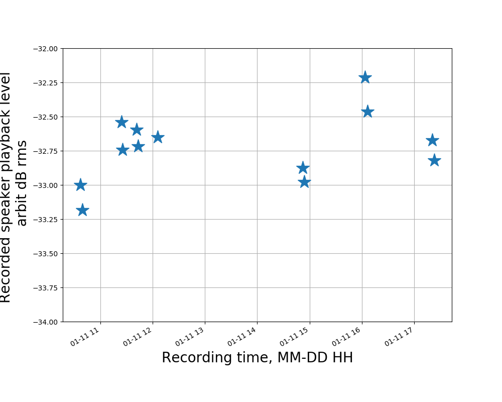

```python
plt.figure(figsize=(10,8))
plt.plot(time_stamps, 20*np.log10(playback_levels), '*', markersize=20)
plt.gcf().autofmt_xdate()
plt.ylabel('Recorded speaker playback level \n arbit dB rms', fontsize=20)
plt.xlabel('Recording time, MM-DD HH', fontsize=20); plt.ylim(-34, -32)
plt.grid()
```

### The speaker playback is constant to within 1 dB !

#### Across the ~6 hours that the playback was done over (with gaps etc.) the recorded playback level of the recordings is constant. This is good news as it indicates that I can trust the Vifa speaker to hold a constant level over this time span.

#### Of course, this is a broad picture as I haven't really looked at how each of the playback signals are varying - but for a quick estimate, this already tells me that each of the signals themselves can't have varied too much - otherwise I would've seen more than 1 dB variation in the recorded level.

# 2 How similar are the SMPs to each other?

#### I have SIXTEEN or more SMP mics that contribute to recordings in my dataset at one point or the other. I *could* do calibration measurements of *each* of the mics - but this is honestly very time consuming. So far, as of Jan 2019 I mananged to only get done with 10 of them. In general however, I still need to know how different they are from each other...

## The analysis plan:

#### The essential idea is to again very *broadly* characterise the on-axis recorded signal levels of each mic. Since I know there is a variation of +/- 1 dB across speaker playbacks, any variation beyond this will indicate microphone individuality.

#### However, here there is a bit complication because each of the mic recordings have different gain settings. I need to account for these gain settings and only then compare the recorded levels across each SMP mic. Having realised that the gain knob markings are not linear, I only used the number of markings from the 30 dB as an indicator.

#### The measured gain values at each knob is the following:

[figure not shown]

#### Acording to this graph then '2marksfrom30dB' means it is +39 dB gain, and '3marksfrom30dB' means it is +46 dB gain.

```python
micname = re.compile(r'SMP.+?\\')
```

```python
#  find the SMP on axis mic recordings:
smp_folders = glob.glob(calibration_folder+'\\SMP*')
all_on_axis_files = []
mic_names = []
for each_mic in smp_folders:
    on_axis = glob.glob(each_mic+'\\'+'SMP*_azimuth_angle_0*')
    for each in on_axis:
        thismic_name = micname.search(each).group()[:-1]

        # remove SMP3_old because the mic doesn't work anymore
        if thismic_name == 'SMP3_old':
            pass
        else:
            mic_names.append(thismic_name)
            all_on_axis_files.append(each)
```

```python
mic_names
```

```
['SMP1_old',
 'SMP2_old',
 'SMP2_prime',
 'SMP3_prime',
 'SMP4_old',
 'SMP5_old',
 'SMP6_old',
 'SMP7_old',
 'SMP7_prime',
 'SMP_8_old']
```

```python
all_on_axis_files
```

```
['H:\\fieldwork_2018_001\\mic_calibrations\\2019-01-10\\myotis_CPN_mics\\SMP1_old\\SMP1_gaindB_2marksfrom30dB_azimuth_angle_0_2019-01-11_15-34-59.wav',
 'H:\\fieldwork_2018_001\\mic_calibrations\\2019-01-10\\myotis_CPN_mics\\SMP2_old\\SMP2_gaindB_2marksfrom30dB_azimuth_angle_00_2019-01-11_15-23-49.wav',
 'H:\\fieldwork_2018_001\\mic_calibrations\\2019-01-10\\myotis_CPN_mics\\SMP2_prime\\SMP2_prime_gaindB_2marksfrom30dB_azimuth_angle_0_2019-01-11_17-53-03.wav',
 'H:\\fieldwork_2018_001\\mic_calibrations\\2019-01-10\\myotis_CPN_mics\\SMP3_prime\\SMP3_prime_gaindB_2marksfrom30dB_azimuth_angle_0_2019-01-11_17-31-21.wav',
 'H:\\fieldwork_2018_001\\mic_calibrations\\2019-01-10\\myotis_CPN_mics\\SMP4_old\\SMP4_old_gaindB_3marksfrom30dB_azimuth_angle_0_2019-01-11_16-57-30.wav',
 'H:\\fieldwork_2018_001\\mic_calibrations\\2019-01-10\\myotis_CPN_mics\\SMP5_old\\SMP5_old_gaindB_2marksfrom30dB_azimuth_angle_0_2019-01-11_17-09-04.wav',
 'H:\\fieldwork_2018_001\\mic_calibrations\\2019-01-10\\myotis_CPN_mics\\SMP6_old\\SMP6_old_gaindB_3marksfrom30dB_azimuth_angle_0_2019-01-11_16-48-45.wav',
 'H:\\fieldwork_2018_001\\mic_calibrations\\2019-01-10\\myotis_CPN_mics\\SMP7_old\\SMP7_old_gaindB_3marksfrom30dB_azimuth_angle_0_2019-01-11_16-35-40.wav',
 'H:\\fieldwork_2018_001\\mic_calibrations\\2019-01-10\\myotis_CPN_mics\\SMP7_prime\\SMP7_prime_gaindB_2marksfrom30dB_azimuth_angle_0_2019-01-11_17-44-52.wav',
 'H:\\fieldwork_2018_001\\mic_calibrations\\2019-01-10\\myotis_CPN_mics\\SMP_8_old\\SMP8_gaindB_2marksfrom30dB_azimuth_angle_0_2019-01-11_12-09-05.wav']
```

```python
# dictionary to map the string to the db gain
markings_to_dB = {'2marksfrom30dB':39, '3marksfrom30dB':46}
```

```python
# search pattern:
gainsetting_pattern = re.compile(r"\dmarksfrom30dB")
```

```python
# highpass at 8 kHz and calculate signal level of the SMP mics:
smps_rec_level = np.zeros(len(all_on_axis_files))
for i, each_file in enumerate(all_on_axis_files):
    smp_rec, fs = sf.read(each_file)
    hp_smp_rec = signal.filtfilt(b,a, smp_rec)
    rms_smp_rec = rms(hp_smp_rec)

    # get the gain value used:
    gainused = str(gainsetting_pattern.search(each_file).group())
    # final dBrms :
    final_dBrms = 20*np.log10(rms_smp_rec) - markings_to_dB[gainused]
    smps_rec_level[i] = final_dBrms
```

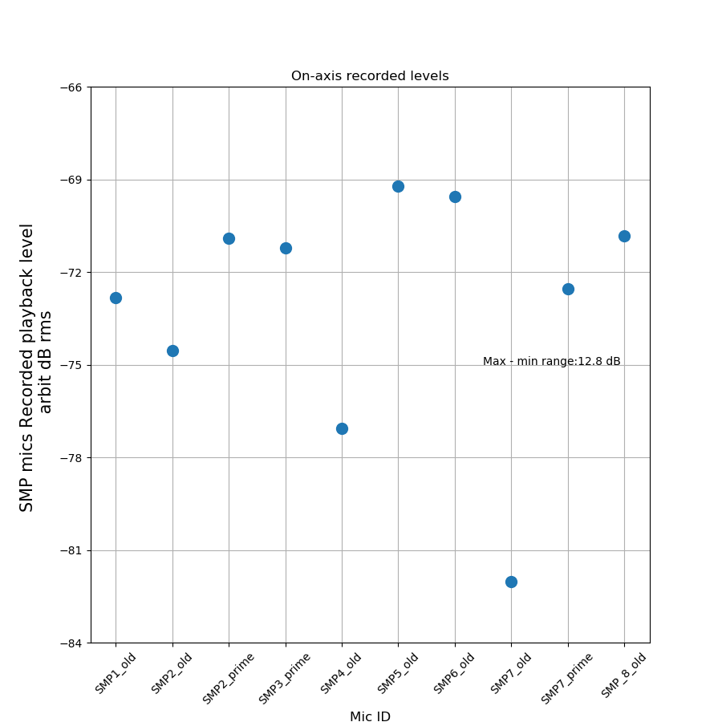

```
Text(0.5,1,'On-axis recorded levels')
```

```python
plt.figure(figsize=(9,9))
plt.plot(smps_rec_level,'.', markersize=20)
plt.xticks(range(len(smps_rec_level)), mic_names, rotation =45);
plt.grid(); plt.ylabel('SMP mics Recorded playback level \n arbit dB rms', fontsize=15)
plt.yticks(np.arange(-84, -63, 3)); plt.xlabel('Mic ID', fontsize=12)
smp_max_min_range = np.round(np.max(smps_rec_level) - np.min(smps_rec_level), 1)
plt.text(6.5, -75, 'Max - min range:' + str(smp_max_min_range) +' dB')
plt.title('On-axis recorded levels')
```

### There is noticeable variation between SMP mics. This means I really do need to pay attention to the identity of the microphone. This makes a big difference in how I will have to approach my microphone calibrations from now on. I need to have a mic calibration approach that's closer to 'ALL or None' rather than 'SOME' while making recordings of the available mics.

# 3 How similar are the SANKENs to each other?

#### The SANKEN CO-100 is a rather fancy condenser microphone designed for high-end studio use. I have 4 of them with serial numbers 1538, 1539, 1545, 1546 -- which I also have numbered according to the Fireface 802 channel assigned to them: #9,#10,#11,#12. I used the same gain settings on all the mics and so it should again be straightforward to compare them to each other.

### The effect of continuous usage ... accident to Mic #10 (1539):

#### Once while using the tristar array with all four SANKENs the whole array fell and the protective grill of the SANKEN 1539 took much of the brunt of this fall. I did not notice any dents in the shiny golden membrance below the grill, and the mic registered signal fairly well. The grill looks rather crumpled in comparison to the other SANKEN mics. I've never tried to quantify the effect of this grill crumpling on mic sensitivity till now.

```python
# sanken mic nae pattern:
sankenmicname = re.compile(r'SANKEN_\d+_\d+')
```

```python
# find on axis SANKEN recordings
all_sanken_folders = glob.glob(calibration_folder+'SANKEN*')

sanken_on_axis_files = []
sanken_mic_id = []
for i,each_sanken in enumerate(all_sanken_folders):
    on_axis_file = glob.glob(each_sanken + '\\'+'SANKEN*_azimuth_angle_0*')
    sanken_on_axis_files.append(on_axis_file[0])
    sanken_mic_id.append(sankenmicname.search(on_axis_file[0]).group())
```

```python
sanken_on_axis_files
```

```
['H:\\fieldwork_2018_001\\mic_calibrations\\2019-01-10\\myotis_CPN_mics\\SANKEN_10_1539\\SANKEN_1539_gaindB_30_azimuth_angle_0_2019-01-11_11-47-24.wav',
 'H:\\fieldwork_2018_001\\mic_calibrations\\2019-01-10\\myotis_CPN_mics\\SANKEN_11_1545\\SANKEN_11_1545_gaindB_30_azimuth_angle_0_2019-01-11_11-29-23.wav',
 'H:\\fieldwork_2018_001\\mic_calibrations\\2019-01-10\\myotis_CPN_mics\\SANKEN_12_1546\\SANKEN_12_1546_aindB_30_azimuth_angle_0_2019-01-11_10-18-20.wav',
 'H:\\fieldwork_2018_001\\mic_calibrations\\2019-01-10\\myotis_CPN_mics\\SANKEN_9_1538\\SANKEN_9_1538_gaindB_30_azimuth_angle_0_2019-01-11_11-11-01.wav']
```

```python
# get recorded levels:
sanken_mic_levels = np.zeros((4))
for i, each_sanken in enumerate(sanken_on_axis_files):
    sanken_rec, fs = sf.read(each_sanken)
    hp_sanken  = signal.filtfilt(b,a,sanken_rec)
    rms_sanken = rms(hp_sanken)
    sanken_mic_levels[i] = rms_sanken
```

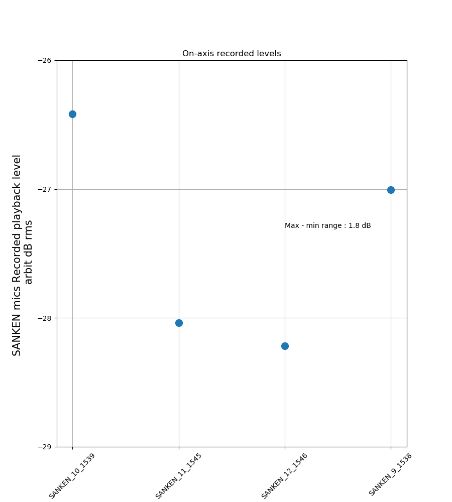

```
Text(0.5,1,'On-axis recorded levels')
```

```python
plt.figure(figsize=(9,10))
plt.plot(20*np.log10(sanken_mic_levels), '.', markersize=20);plt.grid();
plt.yticks(np.arange(-29,-25,1)); plt.ylabel('SANKEN mics Recorded playback level \n arbit dB rms', fontsize=15)
plt.xticks(range(4), sanken_mic_id, rotation=45);
sanken_max_min_range = np.max(20*np.log10(sanken_mic_levels)) - np.min(20*np.log10(sanken_mic_levels))
plt.text(2, -27.3, 'Max - min range : '+str(np.round(sanken_max_min_range,1))+ ' dB')
plt.title('On-axis recorded levels')
```

### The SANKENs show the same effective sensitivity on-axis. The max-min range is 1.8 dB, and considering that the speaker itself varies about 1 dB between playbacks, this means the mics are even closer in their response. Even though SANKEN_10_1539 has a crumpled grill, it is somehow a little bit more sensitive than other mics -- but this is hard to really tease apart given the variation in speaker playback levels <1 dB.

# Getting received sound pressure levels:

#### Having a GRAS microphone with me, it allows a real-life quantitative measurement of the sound pressure level. Given that we're using the same speaker model for playbacks I must be able to

#### a) calculate the received level with a GRAS microphone

#### b) perform microphone IR/frequency response compensation and calculate received level with other microphones

## Calculating received levels of the speaker playback with the GRAS mic:

#### We need to first compare the signal from the calibrator tone with the speaker recordings. The calibrator tone is a pute tone at 1 kHz recorded at a received level of 94 dB SPL re 20 $\mu$Pa

```python
gras_calibrator_recs = []
# find the GRAS calibrator recordings
for each_folder in mic_folders:
    match_results = glob.glob(calibration_folder+each_folder+'\\'+'GRAS*calibrator*.wav')
    if len(match_results) >0:
        for each in match_results:
            gras_calibrator_recs.append(each)

gras_calibrator_recs
```

```
['H:\\fieldwork_2018_001\\mic_calibrations\\2019-01-10\\myotis_CPN_mics\\SANKEN_10_1539\\GRAS_gaindB_70_calibrator_angle_0_2019-01-11_12-09-04.wav',
 'H:\\fieldwork_2018_001\\mic_calibrations\\2019-01-10\\myotis_CPN_mics\\SANKEN_10_1539\\GRAS_gaindB_70_calibrator_angle_0_2019-01-11_12-09-20.wav',
 'H:\\fieldwork_2018_001\\mic_calibrations\\2019-01-10\\myotis_CPN_mics\\SANKEN_12_1546\\GRAS_gaindB_70_calibrator_angle_0_2019-01-11_11-09-17.wav',
 'H:\\fieldwork_2018_001\\mic_calibrations\\2019-01-10\\myotis_CPN_mics\\SMP1_old\\GRAS_gaindB_70_calibrator_angle_0_2019-01-11_16-09-17.wav',
 'H:\\fieldwork_2018_001\\mic_calibrations\\2019-01-10\\myotis_CPN_mics\\SMP1_old\\GRAS_gaindB_70_calibrator_angle_0_2019-01-11_16-09-32.wav']
```

```python
# remove unusual recordings:
remove_wholerec = 'GRAS_gaindB_70_calibrator_angle_0_2019-01-11_16-09-17.wav' # the recording is interrupted in the middle somehow
# note the weird saturation of the signal between 0-1 second
remove_firstsecond = 'GRAS_gaindB_70_calibrator_angle_0_2019-01-11_12-09-20.wav'
```

```python
b_3k, a_3k = signal.butter(4, 3000/96000.0, 'lowpass') # lowpass at 3 kHz
```

```python
get_filename = re.compile(r'GRAS_.+wav')
```

```python
# load each calibrator tone recording and calculate pp and dB rms:
calibrator_msmts = {'p2p':[],
                    'rms':[],
                    'peak':[]}

for each_rec in gras_calibrator_recs:
    rec_filename = get_filename.search(each_rec).group()
    if rec_filename == remove_wholerec:
        pass
    else:
        audio, fs = sf.read(each_rec)

        if rec_filename == remove_firstsecond:
            audio = audio[192000:]

        audio_lp = signal.filtfilt(b_3k, a_3k, audio)
        p2p_val_max,p2p_val_min  = np.percentile(audio_lp,[99,1])
        p2p_val = p2p_val_max - p2p_val_min
        rms_val = rms(audio_lp) # dB re 1
        peak_val = np.percentile(np.abs(audio_lp),99)# dB re 1

        calibrator_msmts['p2p'].append(p2p_val)
        calibrator_msmts['rms'].append(rms_val)
        calibrator_msmts['peak'].append(peak_val)
```

```python
np.round(np.mean(20*np.log10(calibrator_msmts['peak'])))
```

```
-5.0
```

```python
np.round(np.mean(20*np.log10(calibrator_msmts['rms'])))
```

```
-8.0
```

```python
# check for the expected difference of 3 dB between peak to peak and rms:
np.mean(20*np.log10(calibrator_msmts['peak'])) - np.mean(20*np.log10(calibrator_msmts['rms']))
```

```
3.2301984818240088
```

#### Lesson #1 : Outliers mess with peak and peak-to-peak readings *heavily*. I was initially unable to obtain the 3dB difference between the rms and peak values of the sinusoidal wave. This was because for whatever reason - there are some strange fluctuations in the recorded calibrator signal - that didn't disappear even after low-pass filtering! When you have even one of them in the recording - they can heavily affect the expected readings becaus they push the averages strongly. I instead now chose to use a percentile approach. Since the sine-waves are regular with very few such weird outlier values, my argument is that it's safer to use the percentiles -- and having implemented it I can now recover the 3 dB relationship!!

##### Multiple 1 kHz calibration tones recorded by GRAS. Box in red shows the unexplained high peak values.

[figure not shown]

## The clip level :

#### The clip level of the Fireface 802 is the sound pressure level at which the maximum possible value is reached (+1 or -1). This is calculated by comparing the peak levels of a calibrated tone. Let's do this for our system:

#### The peak level of the calibration tone is : -5 dB peak re 1

#### The calibration tone is a signal produced with 94 dB SPL re 20 $\mu$Pa, and was recorded with 70 dB gain. This means that the actual signal level was -75 dB re 1. This in turn means that the original clip level of the recording system is 94 + 75 = 169 dB peak SPL

#### Similarly for the rms level , it was -8 dB rms re 1. The original signal was thus recorded at -78 dB rms.

#### The clip rms level of the system is thus 94 + 78 = 172 dB rms SPL

## The received level of the speaker playbacks:

### Let's try to calculate the received level of the speaker playbacks with the GRAS microphone first.

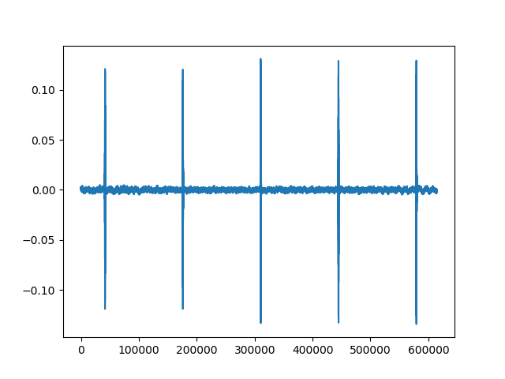

```python
# take one exmaple recording:
sweeps_start, sweeps_end = 1.5, 4.7
one_gras_rec, fs  = sf.read(GRAS_recordings[0], start=int(fs*sweeps_start),
                           stop=int(fs*sweeps_end))
plt.figure()
plt.plot(one_gras_rec)
```

```python
# make template sweep:

# Create the calibration chirp :
chirp_durn = 0.010
t_chirp = np.linspace(0,chirp_durn, int(fs*chirp_durn))
start_f, end_f = 15000, 95000
sweep = signal.chirp(t_chirp,start_f, t_chirp[-1], end_f, 'linear')
sweep *= signal.tukey(sweep.size, 0.9)
sweep *= 0.5

cc = signal.correlate(one_gras_rec, sweep, 'same')
cc_peaks = peak.indexes(cc, 0.85, int(fs*0.35))
```

```python
window_15ms = np.zeros(int(fs*0.015))
numsamples_7pt5ms = int(fs*0.0075)
all_sweeps = np.tile(window_15ms, 5).reshape(5,-1)
for i, each_pk in enumerate(cc_peaks):
    all_sweeps[i,:] = one_gras_rec[each_pk-numsamples_7pt5ms:each_pk+numsamples_7pt5ms]
```

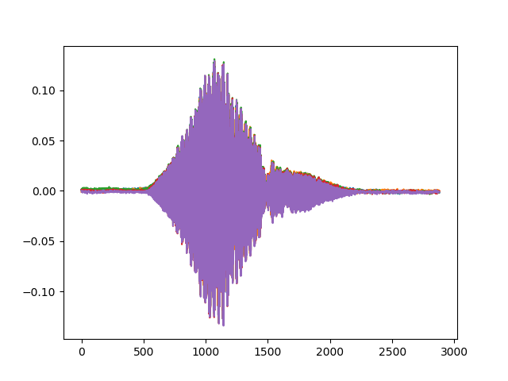

```python
# overlay them all to see if you're getting the main sweep and have aligned them properly.
plt.figure()
for i in range(5):
    plt.plot(all_sweeps[i,:])
```

```python
# highpass filter at 8k and calculate peak and rms
def calc_sweep_params(rec_sweep):
    b,a = signal.butter(2, 8000/96000.0, 'highpass')
    hp_sweep = signal.filtfilt(b,a, rec_sweep)
    peak_val = np.max(np.abs(hp_sweep))
    rms_val = rms(hp_sweep)
    return(peak_val, rms_val)
```

```python
all_peaks = []
all_rms = []
for each_row in range(5):
    peakval, rmsval = calc_sweep_params(all_sweeps[each_row,:])
    all_peaks.append(peakval)
    all_rms.append(rmsval)
```

```python
169 -70 + np.round(np.mean(20*np.log10(all_peaks)))
```

```
81.0
```

```python
172 -70 + np.round(np.mean(20*np.log10(all_rms)))
```

```
71.0
```

#### The sweeps were recorded at -18 dB pe re1 and -31 dB rms re 1 after 70 dB amplification. This means the original signal level is -88 dB peak re 1 and -101 dB rms re 1. The clip level of the system is 169 dB pe SPL and 172 dB rms SPL.

#### This means the received level of the sweeps are :

#### 169 - 88 = 81 dB peak SPL re 20 $\mu$Pa

#### 172 - 101 = 71 dB rms SPL re 20 $\mu$Pa

```python
gras_sweep_received_levels = {}
gras_sweep_received_levels['dBpe_SPL'] = 81
gras_sweep_received_levels['dBrms_SPL'] = 71
```

## Getting received levels from non calibration microphone recordings:

#### This requires me to first find the frequency response curve for each microphone, compensate the audio for it, and then perform the estimation of received level.

```python
# get one GRAS mic recording
gras_pbk_rec, fs = sf.read(GRAS_recordings[0])
gras_pbk_hp = signal.filtfilt(b,a, gras_pbk_rec)

# deattenuate to get original soundcard levels:
gras_pbk_hp *= 10**(-70.0/20)

sanken_hp_deat = np.copy(hp_sanken)
sanken_hp_deat *= 10**(-30/20.0)
```

```python
# let's take a look at the frequency content of the whole playback from the GRAS mic:
gras_fft = np.fft.fft(gras_pbk_hp)
freqs = np.fft.fftfreq(gras_pbk_hp.size, 1.0/fs)
positive_inds = np.argwhere(freqs>=0)
pos_freqs = freqs[positive_inds]

sanken_fft = np.fft.fft(sanken_hp_deat)
```

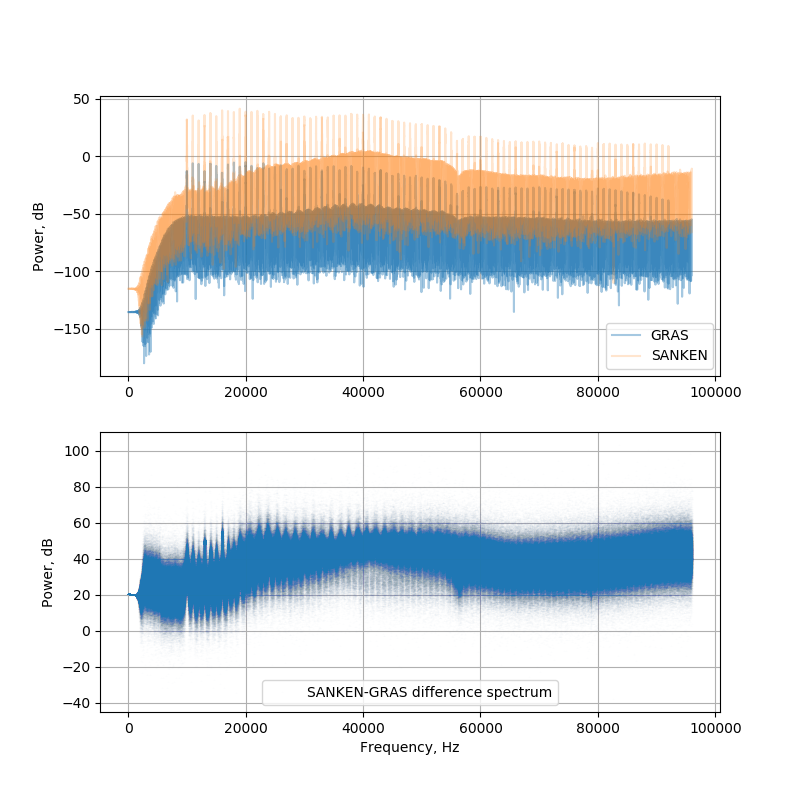

```python
plt.figure(figsize=(8,8))
a0 = plt.subplot(211)
plt.plot(pos_freqs, 20*np.log10(abs(gras_fft[positive_inds])), alpha=0.4, label='GRAS')
plt.plot(pos_freqs, 20*np.log10(abs(sanken_fft[positive_inds])), alpha=0.2, label='SANKEN')
plt.ylabel('Power, dB')
plt.grid()
plt.legend()
plt.subplot(212, sharex=a0)
plt.plot(pos_freqs, 20*np.log10(abs(sanken_fft[positive_inds]))-20*np.log10(abs(gras_fft[positive_inds])), '*',
        label='SANKEN-GRAS difference spectrum', alpha=0.01, markersize=0.5)
plt.ylabel('Power, dB'); plt.xlabel('Frequency, Hz')
plt.legend()
plt.grid()
```

### Getting received levels of speaker playback from GRAS mic recordings:

#### Some details in the implementation :

#### As usual something has gone unnoticed during the playback recordings itself. The recordings only happened till 92 kHz !! Of course in the actual calibration details it doesn't matter so much, because I'm losing the upper ~3 kHz that are close to the Nyquist frequency anyway. The reason this happened was because of the large buffer size I used and the delay in playback+recording.

#### Let's now compare the actual power at each frequency between 10 - 94 kHz. Because I'm taking the whole recording as such, it will also mean I'm taking the linear sweep into account too - but I think it shouldn't make such a big difference overall.

```python
def generate_calibration_playback_sequence():
    '''Code copied from the microphone_calib_playbacks script
    '''

    fs = 192000

    # define a common pl.ayback sounds length:
    common_length = 0.7
    numsamples_comlength = int(fs*common_length)

    # Create the calibration chirp :
    chirp_durn = 0.010
    t_chirp = np.linspace(0,chirp_durn, int(fs*chirp_durn))
    start_f, end_f = 15000, 95000
    sweep = signal.chirp(t_chirp,start_f, t_chirp[-1], end_f, 'linear')
    sweep *= signal.tukey(sweep.size, 0.9)
    sweep *= 0.5

    silence_durn = 0.3
    silence_samples = int(silence_durn*fs)
    silence = np.zeros(silence_samples)
    # create 5 sweeps with silences before & after them :
    sweep_w_leftsilence = np.concatenate((silence,sweep))
    numsamples_to_add = numsamples_comlength - sweep_w_leftsilence.size
    sweep_w_silences = np.concatenate((sweep_w_leftsilence,np.zeros(numsamples_to_add)))
    sweep_w_silences = np.float32(sweep_w_silences)

    all_sweeps = []
    #make a set of 5 sweeps in a row =
    for i in range(5):
        all_sweeps.append(sweep_w_silences)

    # create a set of sinusoidal pulses :
    pulse_durn = 0.1
    pulse_samples = int(fs*pulse_durn)
    t_pulse = np.linspace(0,pulse_durn, pulse_samples)
    pulse_start_f, pulse_end_f  = 10000, 95000
    frequency_step = 1000;
    freqs = np.arange(pulse_start_f, pulse_end_f, frequency_step)

    all_freq_pulses = []
    i = 0
    for each_freq in freqs:
        one_tone = np.sin(2*np.pi*t_pulse*each_freq)
        one_tone *= signal.tukey(one_tone.size, 0.85)

        if each_freq >=80000:
            one_tone *= 0.75
        else:
            one_tone *= 0.5
        one_tone_w_silences = np.float32(np.concatenate((silence,one_tone,silence)))
        all_freq_pulses.append(one_tone_w_silences)

    # setup the speaker playbacks to first play the sweeps and then
    # the pulses :
    playback_sounds = [all_sweeps, all_freq_pulses]
    return(playback_sounds)
```

```python
pbk_sequence = np.concatenate(generate_calibration_playback_sequence()).flatten()
pbk_duration = pbk_sequence.size/192000.0
pbk_duration
```

```
63.0
```

```python
# cross correlate a single sweep w the first recorded sweep. Ideally the delay should be placed at 0.305 seconds
# as the sweep starts at 0.3 and ends at 0.31
delay = signal.correlate(calib_rec[:int(fs*2)], pbk_sequence[int(0.3*fs):int(0.31*fs)], 'same')
```

```python
print(delay.size, calib_rec[:int(fs*2)].size)
```

```
(384000, 384000)
```

```python
now_d = np.argmax(delay)
actual_delay = now_d/float(fs)
print(actual_delay, 'seconds delay in playback')
```

```
(1.7185520833333334, 'seconds delay in playback')
```

```python
calib_rec[now_d:].size/int(0.7*fs)
```

```
87
```

```python
calib_rec_timealigned = calib_rec[now_d-961-int(0.3*fs):]
```

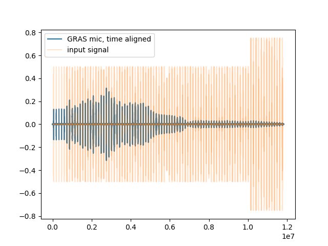

```python
plt.figure()
plt.plot(calib_rec_timealigned, label='GRAS mic, time aligned')
plt.plot(pbk_sequence[:calib_rec_timealigned.size], alpha=0.2, label='input signal')
plt.legend()
```

```python
# and now separate out each and every one of the recorded sounds:
sweep_names = ['sweep_'+str(i) for i in range(1,6)]
tone_names = [freq for freq in np.arange(10000,93000,1000)]
all_sound_ids  = sweep_names + tone_names

all_sound_snippets = {}
for i, sound in enumerate(all_sound_ids):
    all_sound_snippets[sound] = calib_rec_timealigned[int(i*fs*0.7):int((i+1)*fs*0.7)]
```

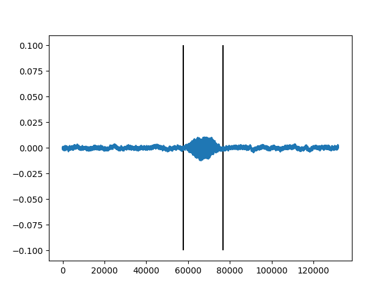

```python
plt.figure()
#plt.plot(calib_rec_timealigned[int(fs*0.7*4):int(fs*0.7*5)])
plt.plot(all_sound_snippets[92000])
plt.vlines([int(0.3*fs),int(0.4*fs)],-0.1,0.1)
```

```python
all_sound_msmts = {}

for freq, snippet in sorted(all_sound_snippets.iteritems()):

    if not isinstance(freq, str):
        all_sound_msmts[freq] = {}
        # bandpass to 2  kHz of target frequency
        b,a = signal.butter(2, np.array([freq-2000, freq+2000])/(fs*0.5), 'bandpass')
        bp_snippet = signal.filtfilt(b,a,snippet)
        all_sound_msmts[freq]['bp_snippet'] = bp_snippet

        # separate tone from background silence and calculate SNR, rms, peak values
        tone = bp_snippet[int(0.3*fs):int(0.4*fs)]
        none_tone = np.concatenate((bp_snippet[:int(0.3*fs)],bp_snippet[int(0.4*fs):]))

        rms_signal = rms(tone)
        all_sound_msmts[freq]['dB_rms'] = 20*np.log10(rms_signal)
        all_sound_msmts[freq]['dB_peak'] = 20*np.log10(np.percentile(abs(tone),99))
        rms_noise = rms(none_tone)
        dB_SNR = 20*np.log10(rms_signal/rms_noise)
        all_sound_msmts[freq]['dB_SNR'] = dB_SNR
```

```python
tones_dBrms = []
tones_dBpeak = []
for freq, msmts in sorted(all_sound_msmts.iteritems()):
    tones_dBrms.append(msmts['dB_rms'])
    tones_dBpeak.append(msmts['dB_peak'])
```

#### Converting the dB peak to SPL, and dB rms to SPL

#### We know the clip level of the recording system is 169 dB SPL (0dB peak), now, let's first compensate for the gain of our system, which means we subtract 70 dB from the current peak values. The same logive will apply for the dB rms measurements too.

```python
tones_deat_peak = np.array(tones_dBpeak) - 70
tones_deat_rms = np.array(tones_dBrms) - 70
```

```python
tones_deat_peak-tones_deat_rms
```

```
array([ 6.2365256 ,  6.21300592,  6.26008549,  6.27139401,  6.2443037 ,
        6.20759731,  6.26062253,  6.22693814,  6.21931974,  6.22397479,
        6.22689823,  6.22573129,  6.27128581,  6.24802994,  6.30654392,
        6.26486961,  6.27092764,  6.28043651,  6.26823065,  6.27968229,
        6.25519602,  6.25839839,  6.27513271,  6.26065232,  6.24922131,
        6.24111236,  6.1849233 ,  6.2375278 ,  6.22927876,  6.24907077,
        6.24046408,  6.25330594,  6.27153467,  6.27351436,  6.27029511,
        6.25930197,  6.24266238,  6.24838591,  5.67754071,  6.25385401,
        6.27205256,  6.22371258,  6.23744778,  6.26622199,  6.29033683,
        6.26777276,  6.22541681,  6.30196473,  6.28219908,  6.27669873,
        6.30512847,  6.28352395,  6.29249499,  6.29213877,  6.02151836,
        6.280493  ,  6.27653745,  6.27942446,  6.28763149,  6.29713222,
        6.29068034,  6.27648437,  6.16574785,  6.28141074,  6.28641854,
        6.28279027,  6.28817076,  6.28743507,  6.28919175,  6.28536731,
        6.24028086,  6.27873679,  6.28266626,  6.29394853,  6.24970536,
        6.28584671,  6.28605563,  6.28586585,  6.27938547,  6.26687933,
        6.28559532,  6.27992021,  6.28353672])
```

#### And now, since we know that 169 dB SPL re 20 $\mu$Pa is the clip level, we can find the actual received levels by subtracting the deattenuated levels - since it is also in dB. For instanc, if the peak level is -39 dB , then we know that the received level is : 169 - 39 --> 130 dB SPL.

```python
clip_level_peakdBSPL = 169
tones_received_level_peak = clip_level_peakdBSPL+tones_deat_peak

clip_level_rmsdBSPL = 172
tones_received_level_rms = clip_level_rmsdBSPL+tones_deat_rms
```

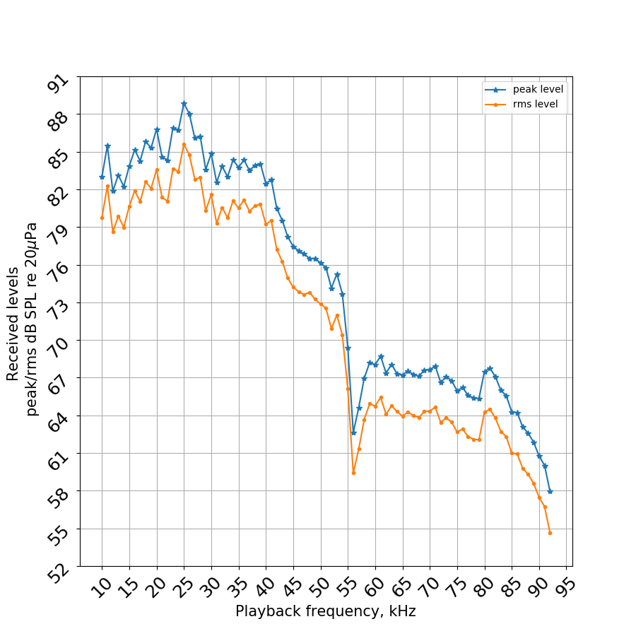

```python
plt.figure(figsize=(9,9))
plt.plot(np.arange(10,93,1), tones_received_level_peak ,'*-', label='peak level')
plt.plot(np.arange(10,93,1), tones_received_level_rms ,'.-', label='rms level')

plt.xticks(np.arange(10,100,5), rotation=45, fontsize=18)
plt.ylabel('Received levels \n peak/rms dB SPL re 20$\mu$Pa', fontsize=15)
plt.grid();plt.xlabel('Playback frequency, kHz', fontsize=15)
plt.yticks(np.arange(52, 93,3), rotation=45, fontsize=18);plt.legend()
```

### Let's do an analogous measurement of the dB rms - if everything is right - the values should just be 3 dB lower than the dB peak since we're working with sinusoidal tones!

```python
tones_received_level_peak - tones_received_level_rms
```

```
array([ 3.2365256 ,  3.21300592,  3.26008549,  3.27139401,  3.2443037 ,
        3.20759731,  3.26062253,  3.22693814,  3.21931974,  3.22397479,
        3.22689823,  3.22573129,  3.27128581,  3.24802994,  3.30654392,
        3.26486961,  3.27092764,  3.28043651,  3.26823065,  3.27968229,
        3.25519602,  3.25839839,  3.27513271,  3.26065232,  3.24922131,
        3.24111236,  3.1849233 ,  3.2375278 ,  3.22927876,  3.24907077,
        3.24046408,  3.25330594,  3.27153467,  3.27351436,  3.27029511,
        3.25930197,  3.24266238,  3.24838591,  2.67754071,  3.25385401,
        3.27205256,  3.22371258,  3.23744778,  3.26622199,  3.29033683,
        3.26777276,  3.22541681,  3.30196473,  3.28219908,  3.27669873,
        3.30512847,  3.28352395,  3.29249499,  3.29213877,  3.02151836,
        3.280493  ,  3.27653745,  3.27942446,  3.28763149,  3.29713222,
        3.29068034,  3.27648437,  3.16574785,  3.28141074,  3.28641854,
        3.28279027,  3.28817076,  3.28743507,  3.28919175,  3.28536731,
        3.24028086,  3.27873679,  3.28266626,  3.29394853,  3.24970536,
        3.28584671,  3.28605563,  3.28586585,  3.27938547,  3.26687933,
        3.28559532,  3.27992021,  3.28353672])
```

## Repeating the pure tone measurements with a SANKEN microphone!

```python
sanken_rec_timealigned = sanken_rec[now_d-961-int(0.3*fs):]
```

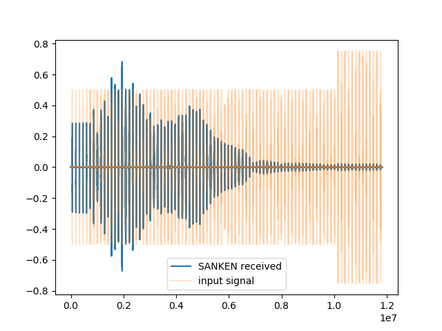

```python
plt.figure()
plt.plot(sanken_rec_timealigned, label='SANKEN received')
plt.plot(pbk_sequence[:calib_rec_timealigned.size], alpha=0.2, label='input signal')
plt.legend()
```

```python
all_sanken_snippets = {}
for i, sound in enumerate(all_sound_ids):
    all_sanken_snippets[sound] = sanken_rec_timealigned[int(i*fs*0.7):int((i+1)*fs*0.7)]
```

```python
all_sanken_msmts = {}

for freq, snippet in sorted(all_sanken_snippets.iteritems()):

    if not isinstance(freq, str):
        all_sanken_msmts[freq] = {}
        # bandpass to 2  kHz of target frequency
        b,a = signal.butter(2, np.array([freq-2000, freq+2000])/(fs*0.5), 'bandpass')
        bp_snippet = signal.filtfilt(b,a,snippet)
        all_sanken_msmts[freq]['bp_snippet'] = bp_snippet

        # separate tone from background silence and calculate SNR, rms, peak values
        tone = bp_snippet[int(0.3*fs):int(0.4*fs)]
        none_tone = np.concatenate((bp_snippet[:int(0.3*fs)],bp_snippet[int(0.4*fs):]))

        rms_signal = rms(tone)
        all_sanken_msmts[freq]['dB_rms'] = 20*np.log10(rms_signal)
        all_sanken_msmts[freq]['dB_peak'] = 20*np.log10(np.percentile(abs(tone),99))
        rms_noise = rms(none_tone)
        dB_SNR = 20*np.log10(rms_signal/rms_noise)
        all_sanken_msmts[freq]['dB_SNR'] = dB_SNR
```

```python
tones_dBrms_sanken = []
tones_dBpeak_sanken = []
for freq, msmts in sorted(all_sanken_msmts.iteritems()):
    tones_dBrms_sanken.append(msmts['dB_rms'])
    tones_dBpeak_sanken.append(msmts['dB_peak'])
```

```python
norm_to_max = lambda X: X - np.max(X)
```

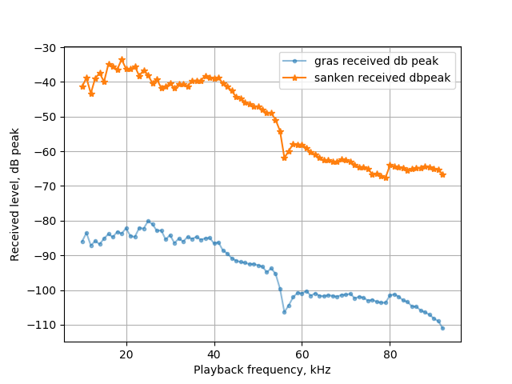

```python
plt.figure()
plt.plot(np.arange(10,93,1),np.array(tones_dBpeak)-70, '.-',alpha=0.5, label='gras received db peak')
plt.plot(np.arange(10,93,1),np.array(tones_dBpeak_sanken)-30, '*-',label='sanken received dbpeak')
plt.ylabel('Received level, dB peak');plt.xlabel('Playback frequency, kHz')
plt.legend();plt.grid();
```

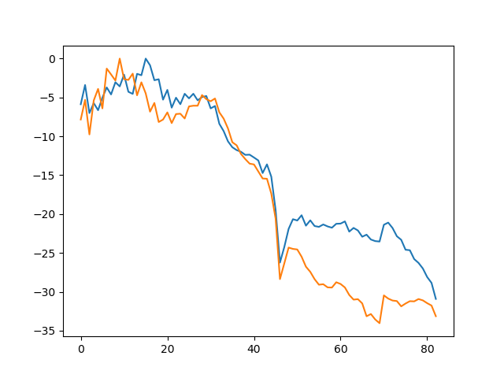

```python
plt.figure()
plt.plot(norm_to_max(tones_dBpeak))
plt.plot(norm_to_max(tones_dBpeak_sanken))
```

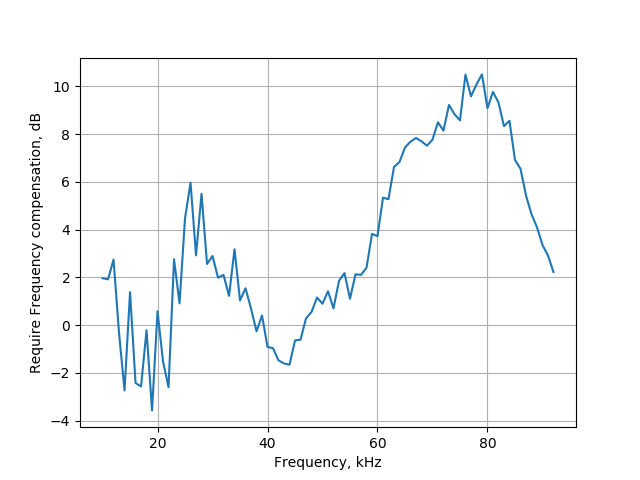

```
Text(0.5,0,'Frequency, kHz')
```

```python
comp_response = norm_to_max(tones_dBpeak)-norm_to_max(tones_dBpeak_sanken)
plt.figure()
plt.plot(np.arange(10,93,1), comp_response)
plt.grid()
plt.ylabel('Require Frequency compensation, dB'); plt.xlabel('Frequency, kHz')
```

```python
# create a filter which will perform the frequency compensation :
freqs = np.hstack((np.arange(0,10000,1000),np.arange(10000,93000,1000), np.arange(93000, 97000,1000)))
amp = np.hstack((np.tile(0,10), 10**(comp_response/20.0), np.tile(0,4)) )
```

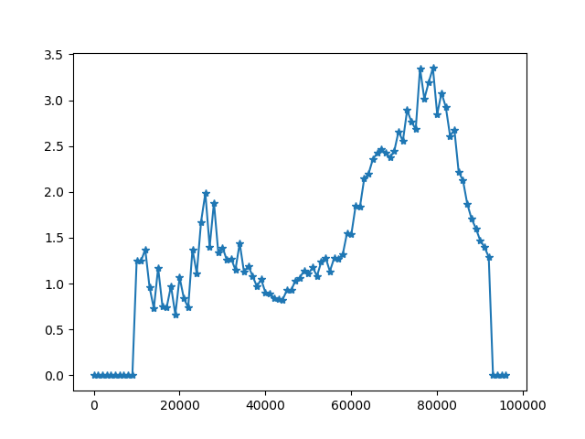

```python
plt.figure()
plt.plot(freqs,amp,'*-')
```

```python
sanken_comp = signal.firwin2(512, freqs, amp, nyq=96000)
```

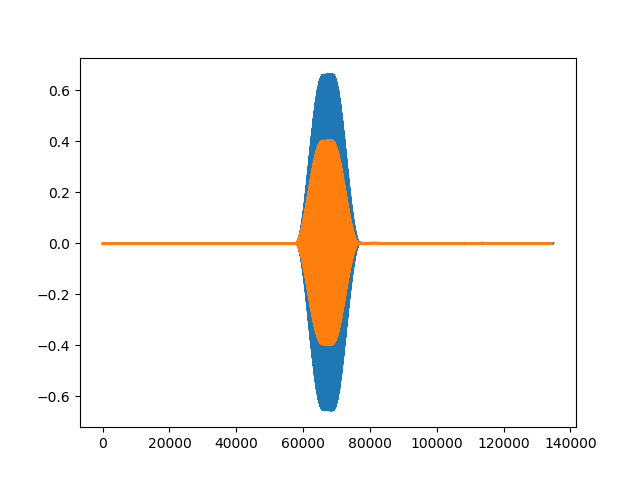

```python
plt.figure()
plt.plot(signal.convolve(all_sanken_snippets[25000], sanken_comp))
plt.plot(all_sanken_snippets[25000])
```

```python
# run measurements after frequency compensation
for freq, snippet in sorted(all_sanken_snippets.iteritems()):

    if not isinstance(freq, str):
        # bandpass to 2  kHz of target frequency
        b,a = signal.butter(2, np.array([freq-2000, freq+2000])/(fs*0.5), 'bandpass')
        comp_snippet = signal.convolve(snippet, sanken_comp, 'same')
        bp_compsnippet = signal.filtfilt(b,a,comp_snippet)
        all_sanken_msmts[freq]['bp_compsnippet'] = bp_compsnippet

        # separate tone from background silence and calculate SNR, rms, peak values
        tone = bp_compsnippet[int(0.3*fs):int(0.4*fs)]
        none_tone = np.concatenate((bp_compsnippet[:int(0.3*fs)],bp_compsnippet[int(0.4*fs):]))

        rms_signal = rms(tone)
        all_sanken_msmts[freq]['dB_rms_comp'] = 20*np.log10(rms_signal)
        all_sanken_msmts[freq]['dB_peak_comp'] = 20*np.log10(np.percentile(abs(tone),99))
        rms_noise = rms(none_tone)
        dB_SNR = 20*np.log10(rms_signal/rms_noise)
        all_sanken_msmts[freq]['dB_SNR_comp'] = dB_SNR
```

```python
# now plot the compensated sanken dB peak values:
tones_comp_dBpeak  = []
tones_comp_dBrms = []
for freq, msmts in sorted(all_sanken_msmts.iteritems()):
    tones_comp_dBpeak.append(msmts['dB_peak_comp'])
    tones_comp_dBrms.append(msmts['dB_rms_comp'])
```

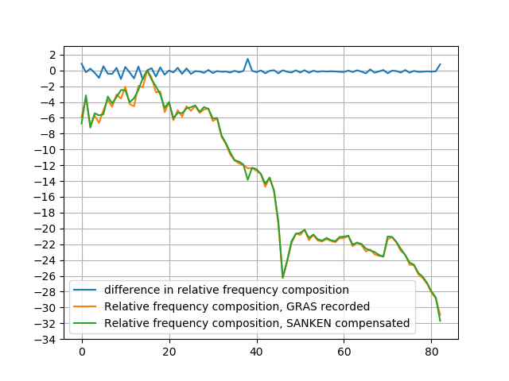

```python
plt.figure()
plt.plot(norm_to_max(tones_dBpeak)-norm_to_max(tones_comp_dBpeak), label='difference in relative frequency composition')
plt.plot(norm_to_max(tones_dBpeak), label='Relative frequency composition, GRAS recorded')
plt.plot(norm_to_max(tones_comp_dBpeak), label='Relative frequency composition, SANKEN compensated')
plt.grid();plt.yticks(np.arange(-34,4,2))
plt.legend()
```

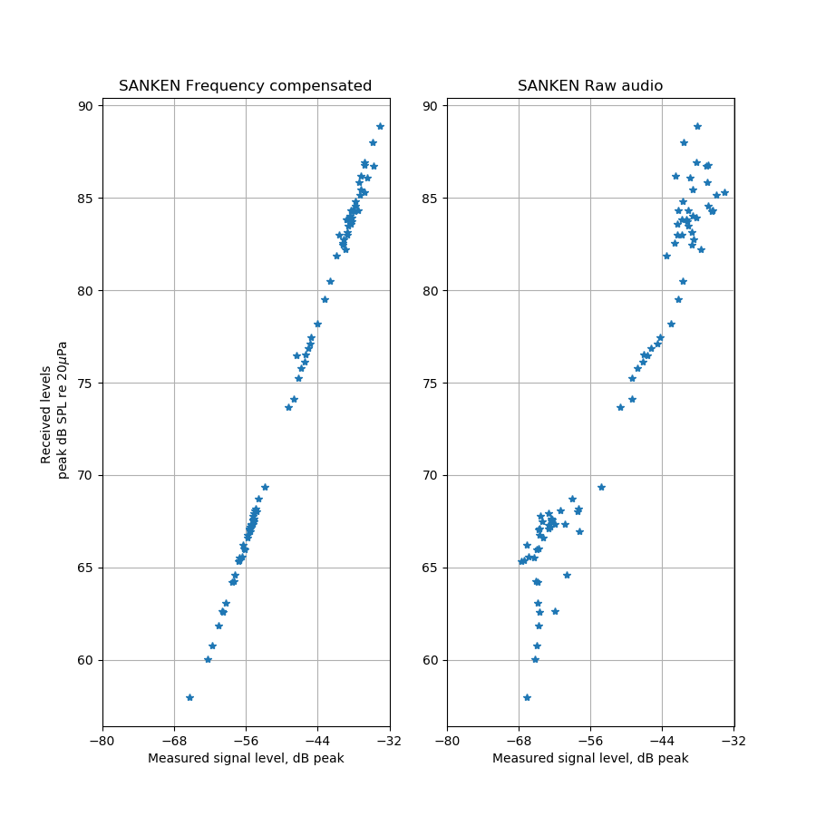

```python
plt.figure(figsize=(9,9))
plt.subplot(121)
plt.title('SANKEN Frequency compensated')
plt.plot(np.array(tones_comp_dBpeak)-30, tones_received_level_peak,'*')
plt.xticks(np.arange(-80,-24,12));plt.grid();plt.ylabel('Received levels \n peak dB SPL re 20$\mu$Pa')
plt.xlabel('Measured signal level, dB peak')
plt.subplot(122)
plt.title('SANKEN Raw audio')
plt.plot(np.array(tones_dBpeak_sanken)-30, tones_received_level_peak,'*')
plt.xticks(np.arange(-80,-24,12));plt.xlabel('Measured signal level, dB peak')
plt.grid()
```

```python
# let's calculate the clip level based on a linear regression of the compensated SANKEN received levels:
from sklearn.linear_model import LinearRegression
comp_rec_level_sanken = (np.array(tones_comp_dBpeak)-30).reshape((-1,1))
reg = LinearRegression().fit(comp_rec_level_sanken, tones_received_level_peak.reshape((-1,1)))
```

```python
# check how well the linear regression works:
pred_rec_levels = reg.predict(comp_rec_level_sanken)
error = tones_received_level_peak.reshape(-1,1) - pred_rec_levels
```

```python
# one dB increase in the dB pe should be equivalent to a one dB increase in received level !
# expected coefficient is 1 - and we're so close !!
reg.coef_
```

```
array([[ 0.99562785]])
```

```python
pred_rec_levels.shape
```

```
(83L, 1L)
```

```python
towards_clip_level = np.arange(-34,1).reshape(-1,1)
pred_to_clip_level = reg.predict(towards_clip_level)
sanken_clip_level = int(np.round(reg.predict(np.array([0]).reshape(-1,1))))
sanken_clip_level
```

```
122
```

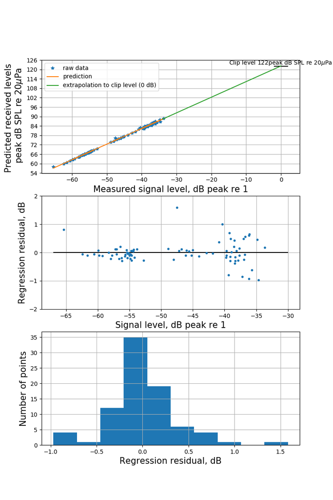

```python
plt.figure(figsize=(8,12))
plt.subplot(311)
plt.plot(comp_rec_level_sanken, tones_received_level_peak,'*',label='raw data')
plt.plot(comp_rec_level_sanken, pred_rec_levels,'-', label='prediction')
plt.plot(towards_clip_level, pred_to_clip_level, '-', label='extrapolation to clip level (0 dB)')
plt.hlines(sanken_clip_level, 2,-2) ; plt.text(-15, sanken_clip_level+1,
                                               'Clip level '+str(sanken_clip_level)+ 'peak dB SPL re 20$\mu$Pa')
plt.ylabel('Predicted received levels \n peak dB SPL re 20$\mu$Pa', fontsize=15);
plt.xlabel('Measured signal level, dB peak re 1', fontsize=15)
plt.grid();plt.legend()
ticks_bothaxes = np.arange(54,132,6)
plt.yticks(ticks_bothaxes)
plt.subplot(312)
plt.plot(comp_rec_level_sanken, error, '.')
plt.hlines(0, -67, -30);plt.yticks(np.arange(-2,3,1))
plt.ylabel('Regression residual, dB', fontsize=15); plt.xlabel('Signal level, dB peak re 1', fontsize=15)
plt.grid()
plt.subplot(313)
plt.hist(error);plt.ylabel('Number of points', fontsize=15);plt.xlabel('Regression residual, dB', fontsize=15);plt.grid()
```

```python
np.percentile(abs(error), [5,95,99,100])
```

```
array([ 0.01890855,  0.84552232,  1.1004565 ,  1.58288301])
```

### Overall, the linear regression has avery good fit. 99% of the abs(prediction errors) are <= 1.1 dB error and the maximum prediction error is 1.6 dB. The clip level of the SANKEN + Fireface system is 122 dB peak SPL re 20$\mu$Pa.

### The big test :

### Now, having come to gotten the clip level of the SANKEN+Fireface system - let's go and measure a more complex signal - the linear sweep. If the frequency compensation and my clip level calculations are correct, then I should get concurrent readings as the GRAS mic measurement.

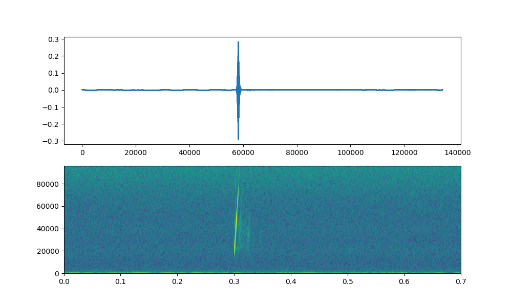

```python
plt.figure(figsize=(10,6))
plt.subplot(211)
plt.plot(all_sanken_snippets['sweep_1'])
plt.subplot(212)
plt.specgram(all_sanken_snippets['sweep_1'], Fs=192000);
```

```python
# compensate for the mic frequency response now:
comp_sweep = [ signal.convolve(all_sanken_snippets['sweep_'+str(i)], sanken_comp,'same') for i in xrange(1,6)]
```

```python
# get the peak amplitude:
peak_vals = [ calc_sweep_params(one_sweep)[0] for one_sweep in comp_sweep ]
# actual received peak amp:
rec_peak_level  = 20*np.log10(peak_vals) - 30
rec_level_pe_SPL = sanken_clip_level + rec_peak_level

rec_level_pe_SPL
```

```
array([ 81.02754586,  81.10530174,  81.10809942,  81.1878331 ,  81.16499532])
```

### E.u.r.e.k.a :

#### The received peak equivalent levels from the GRAS and from the SANKEN MATCH !!!!! I was able to calculate the same received levels with the mics ! This is good news as it tells me my methodology is not completely off !!

### TO BE SURE - check concurrency of dB rms source levels:

```python
reg_rms = LinearRegression()
rec_level_rms = np.array(tones_received_level_rms).reshape(-1,1)
dbrms_sanken = np.array(tones_comp_dBrms).reshape(-1,1)-30
reg_rms.fit(dbrms_sanken, rec_level_rms)
```

```
LinearRegression(copy_X=True, fit_intercept=True, n_jobs=1, normalize=False)
```

```python
# the expected slope is 1 ..and we're so close !
reg_rms.coef_
```

```
array([[ 0.99422747]])
```

```python
error_rms_fit = rec_level_rms - reg_rms.predict(dbrms_sanken)
```

```python
to_rms_clip_level = np.arange(-39,1).reshape(-1,1)
pred_toclip = reg_rms.predict(to_rms_clip_level)
sanken_rms_clip = int(np.round(pred_toclip[-1]))
sanken_rms_clip
```

```
125
```

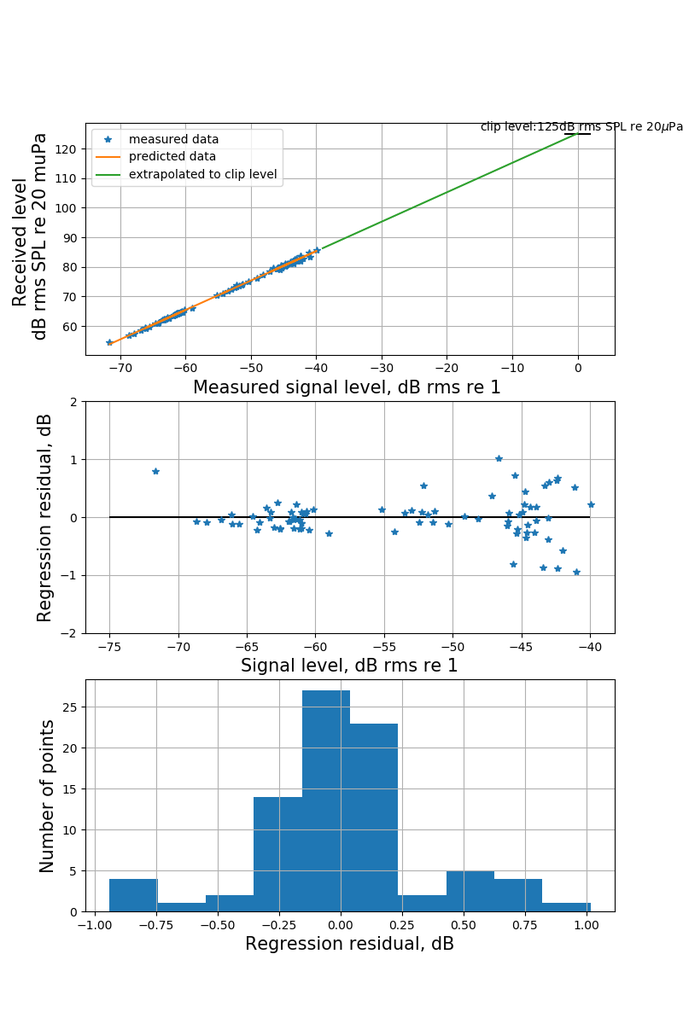

```python
plt.figure(figsize=(8,12))
plt.subplot(311)
plt.plot(dbrms_sanken, tones_received_level_rms, '*', label='measured data')
plt.plot(dbrms_sanken, reg_rms.predict(dbrms_sanken), label='predicted data')
plt.plot(to_rms_clip_level, pred_toclip, label='extrapolated to clip level')
plt.grid();plt.xlabel('Measured signal level, dB rms re 1 ', fontsize=15)
plt.ylabel('Received level \n dB rms SPL re 20 muPa', fontsize=15)
plt.hlines(sanken_rms_clip, -2,2);plt.text(-15,sanken_rms_clip+1,
                                           'clip level:'+str(sanken_rms_clip)+'dB rms SPL re 20$\mu$Pa')
plt.legend()
plt.subplot(312)
plt.plot(dbrms_sanken, error_rms_fit,'*'); plt.hlines(0, -75,-40)
plt.yticks(np.arange(-2,3));plt.grid();plt.ylabel('Regression residual, dB', fontsize=15)
plt.xlabel('Signal level, dB rms re 1', fontsize=15)

plt.subplot(313)
plt.hist(error_rms_fit);
plt.ylabel('Number of points', fontsize=15);plt.xlabel('Regression residual, dB', fontsize=15);plt.grid()
```

```python
# calculate the db rms of the sweep:
start_section = int((0.3-0.0025)*fs)
end_section = int((0.31+0.0025)*fs)
sweep_rms_vals = [ calc_sweep_params(one_sweep[start_section:end_section])[1] for one_sweep in comp_sweep ]

noncomp_sweeps = [ all_sanken_snippets[sweep_num] for sweep_num in ['sweep_1', 'sweep_2', 'sweep_3']]
noncomp_sweeprms = [calc_sweep_params(one_sweep[start_section:end_section])[1] for one_sweep in noncomp_sweeps]

# the received level of the linear sweep is....
sanken_rms_clip + 20*np.log10(sweep_rms_vals)-30
```

```
array([ 71.22174076,  71.41605309,  71.46353789,  71.49302734,  71.50453024])
```

```python
# mean received value
sanken_sweep_received_level = {}
sanken_sweep_received_level['dBrms_SPL'] = int(np.round(np.mean(sanken_rms_clip + 20*np.log10(sweep_rms_vals)-30)))
sanken_sweep_received_level['dBpe_SPL'] = int(np.round(np.mean(rec_level_pe_SPL)))


sanken_sweep_received_level
```

```
{'dBpe_SPL': 81, 'dBrms_SPL': 71}
```

```python
#without the frequency compensation:
sanken_rms_clip + 20*np.log10(noncomp_sweeprms)  - 30
```

```
array([ 70.69498593,  70.85512747,  70.90236093])
```

### E.U.R.E.K.A AGAIN!

#### The SANKEN obtained dB rms values match too!! The 71 dB rms SPL is the same value as that obtained from the GRAS microphone!! The other interesting thing I've noticed is that the difference between the received level of a compensated vs non-compensated sound is < 1 dB... I'm a bit puzzled but this - but this could also be perhaps because the clip level is the major source of error.

#### Once the clip level has been determined correctly, then I guess figuring out the actual received levels may not be as error prone. For instance, if I'd used the non compensated dB peak levels vs dB SPL plot... then clip level estimate would have been off - and so would everything else !

## What about the SMP mics ??

### The SANKEN has a relatively flat frequency response through its response range. The SMP's however aren't thaaat great. Let's apply the SANKEN workflow onto one SMP mic , and see if we can recover the same kind of received levels.

```python
# choose the last smp
each_file
one_smp_rec, fs = sf.read(each_file)
each_file
```

```
'H:\\fieldwork_2018_001\\mic_calibrations\\2019-01-10\\myotis_CPN_mics\\SMP_8_old\\SMP8_gaindB_2marksfrom30dB_azimuth_angle_0_2019-01-11_12-09-05.wav'
```

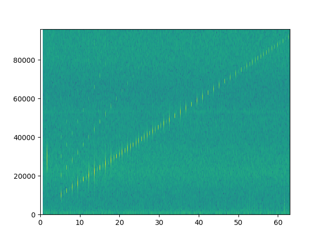

```python
plt.figure()
plt.specgram(one_smp_rec, Fs=fs,);
```

```python
smp_delay = signal.correlate(one_smp_rec[:192000*2], sweep, 'same')
smp_start = np.argmax(smp_delay)-int(0.3*fs)-961
smp_timealigned = one_smp_rec[smp_start:]
smp_timealigned.shape[0]/int(0.7*fs)
```

```
87L
```

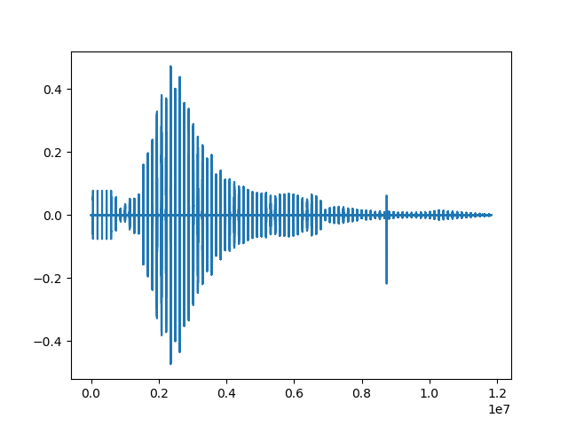

```python
plt.figure()
plt.plot(smp_timealigned)
```

```python
all_smp_snippets = {}
for i, sound in enumerate(all_sound_ids):
    all_smp_snippets[sound] = smp_timealigned[int(i*fs*0.7):int((i+1)*fs*0.7)]
```

```python
all_smp8_msmts = {}

for freq, snippet in sorted(all_smp_snippets.iteritems()):

    if not isinstance(freq, str):
        all_smp8_msmts[freq] = {}
        # bandpass to 2  kHz of target frequency
        b,a = signal.butter(2, np.array([freq-2000, freq+2000])/(fs*0.5), 'bandpass')
        bp_snippet = signal.filtfilt(b,a,snippet)
        all_smp8_msmts[freq]['bp_snippet'] = bp_snippet

        # separate tone from background silence and calculate SNR, rms, peak values
        tone = bp_snippet[int(0.3*fs):int(0.4*fs)]
        none_tone = np.concatenate((bp_snippet[:int(0.3*fs)],bp_snippet[int(0.4*fs):]))

        rms_signal = rms(tone)
        all_smp8_msmts[freq]['dB_rms'] = 20*np.log10(rms_signal)
        all_smp8_msmts[freq]['dB_peak'] = 20*np.log10(np.percentile(abs(tone),99))
        rms_noise = rms(none_tone)
        dB_SNR = 20*np.log10(rms_signal/rms_noise)
        all_smp8_msmts[freq]['dB_SNR'] = dB_SNR
```

```python
tones_dBpeak_smp  = [  msmts['dB_peak'] for freq, msmts in sorted(all_smp8_msmts.iteritems())]
```

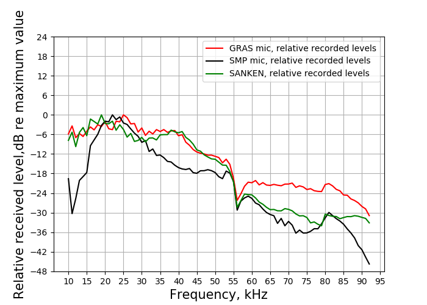

```python
freq_kHz = np.arange(10,93,1)
plt.figure(figsize=(7,5))
plt.plot(freq_kHz, norm_to_max(tones_dBpeak), c='r', label='GRAS mic, relative recorded levels')
plt.plot(freq_kHz, norm_to_max(tones_dBpeak_smp), c='k', label='SMP mic, relative recorded levels')
plt.plot(freq_kHz, norm_to_max(tones_dBpeak_sanken), c='g', label='SANKEN, relative recorded levels')
plt.grid();plt.legend();plt.ylabel('Relative received level,dB re maximum value', fontsize=15)
plt.xlabel('Frequency, kHz', fontsize=15)
plt.xticks(np.arange(10,98,5)); plt.yticks(np.arange(-48,30,6));
```

```python
smp_comp_gain = norm_to_max(tones_dBpeak)-norm_to_max(tones_dBpeak_smp)
```

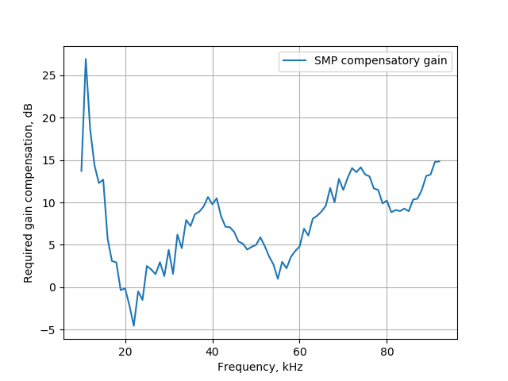

```
Text(0.5,0,'Frequency, kHz')
```

```python
plt.figure()
plt.plot(freq_kHz, smp_comp_gain, label='SMP compensatory gain')
plt.legend();plt.grid(); plt.ylabel('Required gain compensation, dB');plt.xlabel('Frequency, kHz')
```

```python
freqs = np.hstack((np.arange(0,10000,1000),np.arange(10000,93000,1000), np.arange(93000, 97000,1000)))
smp_amps = np.hstack((np.tile(0,10), 10**(smp_comp_gain/20.0),np.tile(0,4)))
smp_comp = signal.firwin2(512, freqs, smp_amps, nyq=96000)
```

```python
# run measurements after frequency compensation
for freq, snippet in sorted(all_smp_snippets.iteritems()):

    if not isinstance(freq, str):
        # bandpass to 2  kHz of target frequency
        b,a = signal.butter(2, np.array([freq-2000, freq+2000])/(fs*0.5), 'bandpass')
        comp_snippet = signal.convolve(snippet, smp_comp, 'same')
        bp_compsnippet = signal.filtfilt(b,a,comp_snippet)
        all_smp8_msmts[freq]['bp_compsnippet'] = bp_compsnippet

        # separate tone from background silence and calculate SNR, rms, peak values
        tone = bp_compsnippet[int(0.3*fs):int(0.4*fs)]
        none_tone = np.concatenate((bp_compsnippet[:int(0.3*fs)],bp_compsnippet[int(0.4*fs):]))

        rms_signal = rms(tone)
        all_smp8_msmts[freq]['dB_rms_comp'] = 20*np.log10(rms_signal)
        all_smp8_msmts[freq]['dB_peak_comp'] = 20*np.log10(np.percentile(abs(tone),99))
        rms_noise = rms(none_tone)
        dB_SNR = 20*np.log10(rms_signal/rms_noise)
        all_smp8_msmts[freq]['dB_SNR_comp'] = dB_SNR
```

```python
tones_dBpeak_smp_comp = [ msmt['dB_peak_comp'] for key,msmt in sorted(all_smp8_msmts.iteritems())]
tones_dBrms_smp_comp = [ msmt['dB_rms_comp'] for key,msmt in sorted(all_smp8_msmts.iteritems())]
```

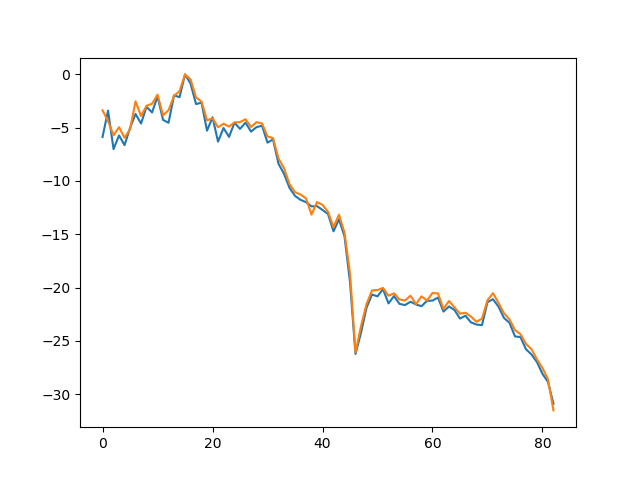

```python
plt.figure()
plt.plot(norm_to_max(tones_dBpeak))
plt.plot(norm_to_max(tones_dBpeak_smp_comp))
total_error = sum(norm_to_max(tones_dBpeak)-norm_to_max(tones_dBpeak_smp_comp))
```

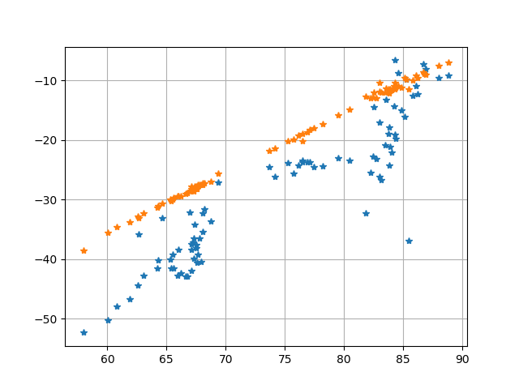

```python
plt.figure()
plt.plot(tones_received_level_peak, tones_dBpeak_smp,'*', label='raw audio received levels')
plt.plot(tones_received_level_peak, tones_dBpeak_smp_comp,'*', label='frequency compensated audio levels')
plt.grid()
```

```python
each_file
```

```
'H:\\fieldwork_2018_001\\mic_calibrations\\2019-01-10\\myotis_CPN_mics\\SMP_8_old\\SMP8_gaindB_2marksfrom30dB_azimuth_angle_0_2019-01-11_12-09-05.wav'
```

```python
smp_dbpeak_comp = np.array(tones_dBpeak_smp_comp).reshape(-1,1) - 39
smp_dbrms_comp = np.array(tones_dBrms_smp_comp).reshape(-1,1) - 39

gras_peSPL = tones_received_level_peak.reshape(-1,1)
gras_rmsSPL = tones_received_level_rms.reshape(-1,1)
```

```python
smp_dbpeak_reg = LinearRegression()
smp_dbrms_reg = LinearRegression()
smp_dbpeak_reg.fit(smp_dbpeak_comp, gras_peSPL)
smp_dbrms_reg.fit(smp_dbrms_comp, gras_rmsSPL)
print(smp_dbpeak_reg.coef_, smp_dbrms_reg.coef_)
```

```
(array([[ 0.99215953]]), array([[ 0.99061442]]))
```

```python
smp_pe_error = gras_peSPL - smp_dbpeak_reg.predict(smp_dbpeak_comp)
smp_rms_error = gras_rmsSPL - smp_dbpeak_reg.predict(smp_dbrms_comp)
```

```python
smp_to_clip = np.arange(-45,1).reshape(-1,1)
smp_clip_val_peak = int(np.round(smp_dbpeak_reg.predict(np.array([0]).reshape(-1,1))))

print(smp_clip_val_peak)
```

```
134
```

```python
smp_clip_val_rms = int(np.round(smp_dbrms_reg.predict(np.array([0]).reshape(-1,1))))
print(smp_clip_val_rms)
```

```
137
```

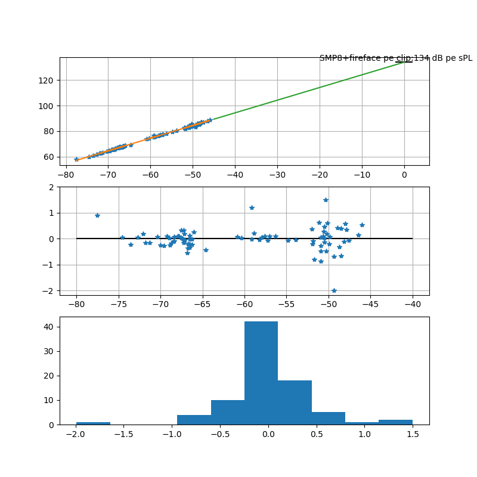

```python
plt.figure(figsize=(8,8))
plt.subplot(311)
plt.plot(smp_dbpeak_comp, gras_peSPL,'*')
plt.plot(smp_dbpeak_comp, smp_dbpeak_reg.predict(smp_dbpeak_comp))
plt.plot(smp_to_clip, smp_dbpeak_reg.predict(smp_to_clip))
plt.hlines(smp_clip_val_peak, -2,2); plt.text(-20, smp_clip_val_peak+1,
                                              'SMP8+fireface pe clip:'+str(smp_clip_val_peak)+' dB pe sPL')
plt.grid()
plt.subplot(312)
plt.plot(smp_dbpeak_comp, smp_pe_error, '*')
plt.hlines(0,-80,-40);plt.grid();plt.yticks(np.arange(-2,3))
plt.subplot(313)
plt.hist(smp_pe_error);
```

```python
# now let's check if the sweeps show the same received value:
smp_sweeps  = [ all_smp_snippets['sweep_'+str(i)] for i in xrange(1,6)]
smp_comp_sweeps = [signal.convolve(one_sweep, smp_comp,'same') for one_sweep in smp_sweeps]
```

```python
# calculate the db rms of the sweep:
start_section = int((0.3-0.0025)*fs)
end_section = int((0.31+0.0025)*fs)
smp_sweep_rms_vals = [ calc_sweep_params(one_sweep[start_section:end_section])[1] for one_sweep in smp_comp_sweeps ]
smp_sweep_pe_vals = [ calc_sweep_params(one_sweep)[0] for one_sweep in smp_comp_sweeps ]
```

```python
smp8_sweep_received_levels={}
```

```python
smp_clip_val_peak + 20*np.log10(smp_sweep_pe_vals)-39
```

```
array([ 81.33629493,  81.33527182,  81.41663129,  81.39595441,  81.39644273])
```

```python
smp_clip_val_rms + 20*np.log10(smp_sweep_rms_vals) - 39
```

```
array([ 71.69939553,  71.71469613,  71.72397492,  71.72983127,  71.72132822])
```

```python
smp8_sweep_received_levels['dBpe_SPL'] = int(np.round(np.mean(smp_clip_val_peak + 20*np.log10(smp_sweep_pe_vals)-39)))
smp8_sweep_received_levels['dBrms_SPL'] = int(np.round(np.mean(smp_clip_val_rms + 20*np.log10(smp_sweep_rms_vals)-39)))
```

```python
sanken_sweep_received_level
```

```
{'dBpe_SPL': 81, 'dBrms_SPL': 71}
```

```python
smp8_sweep_received_levels
```

```
{'dBpe_SPL': 81, 'dBrms_SPL': 72}
```

```python
gras_sweep_received_levels
```

```
{'dBpe_SPL': 81, 'dBrms_SPL': 71}
```

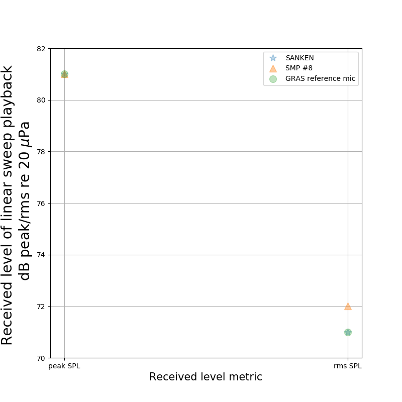

```
Text(0.5,0,'Received level metric')
```

```python
plt.figure(figsize=(8,8))
plt.plot(['peak SPL','rms SPL'],sanken_sweep_received_level.values(),'*',
         markersize=10, alpha=0.3, label='SANKEN')
plt.plot(smp8_sweep_received_levels.values(),'^',markersize=10, alpha=0.4,
        label='SMP #8 ')
plt.plot(gras_sweep_received_levels.values(),'o',markersize=10,alpha=0.3,
        label='GRAS reference mic')
plt.legend();plt.grid();plt.yticks(np.arange(70,84,2));
plt.ylabel('Received level of linear sweep playback \n dB peak/rms re 20 $\mu$Pa', fontsize=20)
plt.xlabel('Received level metric', fontsize=15)
```

## Using the sweeps as a 'calibration' sound.

### In principle, the methodology that I used is not restricted to pure tones. I could compare the frequency composition of any sound recorded from the reference microphone and the non-reference microphone.

```python
b_8to94, a_8to94 = signal.butter(2, np.array([20000, 86000])/96000.0, 'bandpass')
sweep_bp = lambda X : signal.filtfilt(b_8to94, a_8to94, X)



sanken_sweeps_only = [ sweep_bp(one_sweep[start_section:end_section]) for one_sweep in noncomp_sweeps ]
smp_sweeps_only = [ sweep_bp(one_sweep[start_section:end_section]) for one_sweep in smp_sweeps ]
gras_sweeps_only = [ sweep_bp(all_sweeps[i,:]) for i in range(5)]
```

```python
sweeps_spectrum = {}
sweeps_spectrum['GRAS'] = 20*np.log10(abs(np.fft.rfft(gras_sweeps_only[0])))
sweeps_spectrum['SANKEN'] = 20*np.log10(abs(np.fft.rfft(sanken_sweeps_only[0])))
sweeps_spectrum['SMP'] = 20*np.log10(abs(np.fft.rfft(smp_sweeps_only[0])))

sweep_fftfreqs = np.fft.rfftfreq(gras_sweeps_only[0].size, fs**-1.0)
```

```python
# take a silent segment of the recording without any sweep
non_sweep_gras = sweep_bp( gras_pbk_rec[now_d-19200:now_d-19200+gras_sweeps_only[0].size])
```

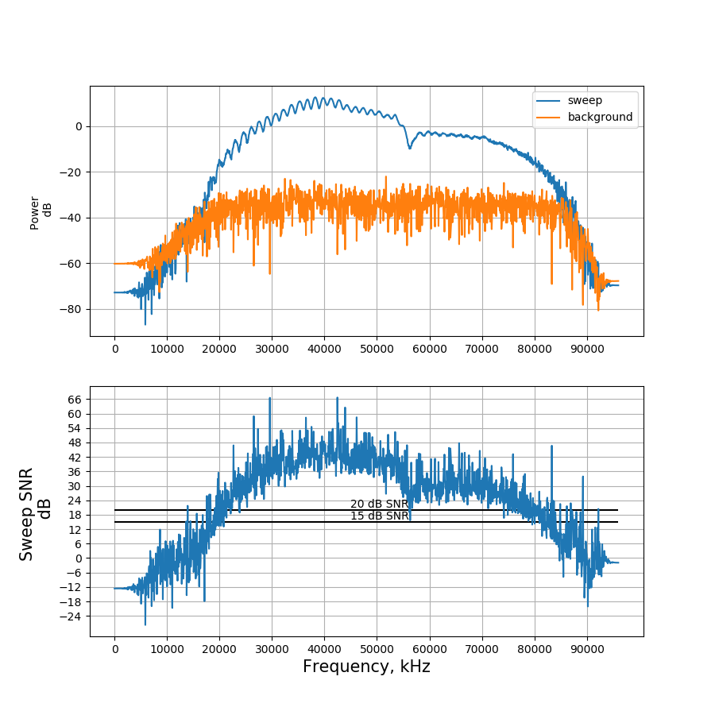

```python
plt.figure(figsize=(9,9))
a0 = plt.subplot(211)
plt.plot(sweep_fftfreqs, sweeps_spectrum['GRAS'], label='sweep')
plt.plot(sweep_fftfreqs, 20*np.log10(abs(np.fft.rfft(non_sweep_gras))), label='background')
plt.grid();plt.xticks(np.arange(0,97000,10000));plt.legend();plt.ylabel('Power \n dB')
a1 = plt.subplot(212, sharex=a0)
plt.plot(sweep_fftfreqs, sweeps_spectrum['GRAS'] - 20*np.log10(abs(np.fft.rfft(non_sweep_gras))))
plt.yticks(np.arange(-24, 72,6));plt.hlines(20, 0,96000);plt.text(45000,21, '20 dB SNR')
plt.hlines(15, 0,96000);plt.text(45000,16, '15 dB SNR');plt.xlabel('Frequency, kHz', fontsize=15)
plt.ylabel('Sweep SNR \n dB', fontsize=15)
plt.grid()
```

### Or.. maybe not.

#### In the interest of now spending too much time figuring out the tiny details of signal processing *and* because my sweeps are anyway rather limited in the recorded bandwidth - I'm deciding to leave out this particular method for another day. As you can see from the graph above, the effective frequency badnwidth above 15 dB SNR lies only within 20-80 kHz or so - which is leave out more than 1/3rd of the available bandwidth ...even if I do manage to get things going I'm just a bit blah right now because of this poor SNR.

#### I'm now going to focus my energies on making a complete software calibration workflow right now - this will allow me to answer the other important questions I have about how much variation there could be in received levels because of mic directionality in the SANKENs, in the SMPs etc.